# MSP4092: Biomatemática: aspectos quantitativos da vida

Aula 1: Número real

[José Siqueira](https://sites.google.com/usp.br/profjosesiqueira)

25 julho 2024 20:44h

```r
invisible(Sys.setlocale("LC_CTYPE", "pt_BR.UTF-8"))
invisible(Sys.setlocale("LC_ALL","pt_BR.UTF-8"))
```

```r
options(warn=-1)
suppressMessages(library(knitr, warn.conflicts=FALSE))
suppressMessages(library(stringr, warn.conflicts=FALSE))
suppressMessages(library(DescTools, warn.conflicts=FALSE))
suppressMessages(library(units, warn.conflicts=FALSE))
suppressMessages(library(crfsuite, warn.conflicts=FALSE))
suppressMessages(library(turner, warn.conflicts=FALSE))
suppressMessages(library(nlsr, warn.conflicts=FALSE))
suppressMessages(library(Deriv, warn.conflicts=FALSE))
suppressMessages(library(REAT, warn.conflicts=FALSE))
```

# Material

- HTML de R Markdown em [`RPubs`](http://rpubs.com/josiqueira/)
- Arquivos em [`GitHub`](https://github.com/josiqueira/BioMat)
- [Prof. José Siqueira: ResearchGate](https://www.researchgate.net/profile/Jose-Siqueira-18)

# Pensamento

“A morte do homem começa no instante em que ele desiste de aprender.”

> Albino Teixeira *apud* Leite (2009)

# Conteúdo

**1. Número real (Capítulo 1)**

2. Função e relação (Capítulo 3)
3. Funções potência, periódica, exponencial e logarítmica (Capítulos 4, 5 e 6)
4. Método gráfico (Capítulo 7)
5. Série e limite (Capítulo 8)
6. Derivada e integral (Capítulo 9 e 10)
7. Equação diferencial ordinária (ODE) (Capítulo 11)
8. Função de duas ou mais variáveis independentes (Capítulo 12)
9. Probabilidade (Capítulo 13)
10. Matriz e vetor (Capítulo 14)

# Livro adotado

- [Batschelet, E](https://de.wikipedia.org/wiki/Eduard_Batschelet) (1979) [*Introduction to mathematics for life scientists*](https://drive.google.com/file/d/1Am3G5ZGXqzXibQwddI12VRQI9mZ9jWYE/view?usp=share_link). 3rd ed. NY: Springer.
- [Batschelet, E](https://de.wikipedia.org/wiki/Eduard_Batschelet) (1978) *Introdução à matemática para biocientistas*. Tradução da 2ª ed. São Paulo: EDUSP e Rio de Janeiro: Interciência.

# Justificativa

A modelagem quantitativa realizada por meio da matemática, estatística e simulação é parte integrante do corpo de disciplinas necessárias para expressar, formular, resolver e comunicar problemas no âmbito das Ciências da Vida, pois ela consiste numa linguagem fundamental para elaborar modelos quantitativos sobre os fenômenos biológicos.

# Material da aula no GoogleDrive

- [Material](https://drive.google.com/drive/folders/1M731rpKtHRwgnMU8faJeOpwm255AjLYv?usp=sharing)

# [Bibliografia](https://drive.google.com/drive/folders/1XBjQidaBIqBbJ7-LSn4rdVp3ywIMZAcq?usp=sharing)

- Allen, LJS (2007) *An Introduction to Mathematical Biology*. NJ: Pearson.
- Batschelet, E (1979) *Introduction to mathematics for life scientists*. 3rd ed. NY: Springer.
- Batschelet, E (1978) *Introdução à matemática para biocientistas*. Tradução da 2ª ed. São Paulo: EDUSP e Rio de Janeiro: Interciência.
- Bloomfield, VA (2014) *Using R for numerical analysis in science and engineering*. USA: CRC.
- Fieller, N (2015) *Basics of matrix algebra for statistics with R*. USA: CRC.
- Garﬁnkel, A et al. (2017) *Modeling Life: The Mathematics of Biological Systems*. USA: Springer.
- Giordano, FR et al. (1997) *A first course in mathematical modeling*. 2nd ed. OH: Thomson.
- Giordano, FR et al. (2015) *A first course in mathematical modeling*. 5th ed. OH: Thomson.
- Hoppenstead, FC & Peskin, CS (1991) *Mathematics in medicine and the life sciences*. NY: Springer.
- Jones, DS, Plank, MJ & Sleeman, BD (2009) *Differential Equations and Mathematical Biology*. 2nd ed. UK: CRC.
- Leite, M (2009) *SciLab: uma abordagem prática e didática*. RJ: Ciência Moderna.
- Massad, E, Menezes, RX, Silveira, PSP & Ortega, NRS (2004) *Métodos quantitativos em medicina*. Manole.
- Neuhauser, C & Roper, ML (2018) *Calculus for Biology and Medicine*. 4th ed. USA: Pearson.
- Nogueira, EA et al. (2008) *Modelos matemáticos nas ciências não-exatas*. SP: Blucher.
- Nooney, GC (1966) Mathematical models in medicine: A diagnosis. *Journal of Chronic* 19(4): 325-32.
- Nowak, MA (2006) *Evolutionary dynamics exploring the equations of life*. USA: Harvard.
- Otto, SP & Day, T (2007) *A biologist’s guide to mathematical modeling in ecology and evolution*. NJ: Princeton.
- Pack, AI & Murray-Smith, DJ (1972) Mathematical models and their applications in medicine. *Scottish Medical Journal* 17(12): 401-9. doi:10.1177/003693307201701205.
- Paiva Jr, FP et al. (2021) *Modelagem matemática e epidemiologia com aplicações*. Curitiba: Appris.
- Pauli, RU et al. (1980) *Física 4: eletricidade, magnetismo, física moderna e análise dimensional*. São Paulo: EPU. O livro apresenta a análise dimensional de forma didática e aplicada em física.
- Simão, C (1980) *Manual do professor de física 4 de Pauli et al.* São Paulo: EPU.
- Rustagi, JS (1971) Mathematical models in medicine. *International Journal of Mathematical Education in Science and Technology* 2(2): 193–203. doi:10.1080/0020739710020209.
- Siqueira, JO (2011) *Fundamentos para cálculo*: usando WolframAlpha. São Paulo: Saraiva. Soluções dos exercícios em https://www.researchgate.net/publication/326533655_Fundamentos_para_Calculo_-_Solucoes.
- Siqueira, JO (2012) *Fundamentos de métodos quantitativos*: aplicados em Administração, Economia, Contabilidade e Atuária usando WolframAlpha e SCILAB. São Paulo: Saraiva. Soluções dos exercícios em https://www.researchgate.net/publication/326533772_Fundamentos_de_metodos_quantitativos_-_Solucoes.
- Thompson, JR (1989) *Empirical model building*. NJ: Wiley.

# Matemática em Inteligência Artificial

- [chatGPT (gratuito)](https://chat.openai.com/)
- [chatGPT (assinado) + WolframAlpha + RStudioGPT](https://chat.openai.com/)
- [Perplexity (gratuito) + WolframAlpha](https://www.perplexity.ai/)
- [Interactive Mathematics](https://app.intmath.com/)

# Matemática em Internet

- [R no Google Colab](https://colab.research.google.com/#create=true&language=r)
- [RStudio Cloud](https://rstudio.cloud/plans/free)
- [WolframAlpha](https://www.wolframalpha.com/)
- [Microsoft Math Solver](https://mathsolver.microsoft.com/pt/solver?f=ep)
- [SCILAB on cloud](https://cloud.scilab.in/)
- [Interactive Mathematics (IA)](https://app.intmath.com/)

# Matemática em App para Android

- [WolframAlpha Apps: Android e iOS](https://products.wolframalpha.com/mobile)
- [Maple Calculator](https://www.maplesoft.com/products/Maplecalculator/)
- [Microsoft Math Solver](https://math.microsoft.com/pt)
- [MATLAB Mobile](https://play.google.com/store/apps/details?id=com.mathworks.matlabmobile&hl=pt_BR&gl=US&pli=1)

# Matemática em Texto na Internet

- [Math is Fun](https://www.mathsisfun.com/index.htm)
- [Math is Fun: Advanced: Limit](https://www.mathsisfun.com/calculus/index.html)
- [LibreTexts Mathematics: Bookshelves](https://math.libretexts.org/Bookshelves)
- [Multivariable calculus: Math Insight](https://mathinsight.org/thread/multivar#sitenav)
- [Prof. José Siqueira no ResearchGate](https://www.researchgate.net/profile/Jose-Siqueira-18)
- https://www.wolfram.com/language/elementary-introduction/2nd-ed/

# Matemática em YouTube

- [Mathematical modeling in biology](https://www.youtube.com/watch?v=LZ_-BdcC7Bk&list=PL5zWDs2j0YF3kPPvs4L5FGlLc7x13Uwjn)
- [Thomas Frank: How to Get Better at Math](https://www.youtube.com/watch?v=HPsazrVSjl8&t=420s)
- [This equation will change how you see the world (the logistic map)](https://www.youtube.com/watch?v=ovJcsL7vyrk)
- [Eric Rowland: An Exact Formula for the Primes: Willans’ Formula](https://www.youtube.com/watch?v=j5s0h42GfvM)
- [The Rhythm of The Primes](https://www.youtube.com/watch?v=8x374slJGuo)
- [D!NG: A Proof That The Square Root of Two Is Irrational](https://www.youtube.com/watch?v=LmpAntNjPj0)
- [Dennis Wildfogel: Quão grande é o infinito?](https://www.youtube.com/watch?v=UPA3bwVVzGI)
- [DontMemorise.com: Logarithms - What is e? | Euler’s Number Explained | Don’t Memorise](https://www.youtube.com/watch?v=_-x90wGBD8U)
- [YouTube: All 6 Trig Functions on the Unit Circle](https://www.youtube.com/watch?v=Dsf6ADwJ66E)
- [Zach Star: The Applications of Matrices | What I wish my teachers told me way earlier](https://www.youtube.com/watch?v=rowWM-MijXU)
- [Dr. Trefor Bazett: Top 4 Algebraic Tricks for Computing Limits](https://www.youtube.com/watch?v=zswMgrZqj4E)
- [Dr. Trefor Bazett: Limits of Oscillating Functions and the Squeeze Theorem](https://www.youtube.com/watch?v=vIRvEvjKM58)
- [Dr. Trefor Bazett: The most important limit in Calculus // Geometric Proof & Applications](https://www.youtube.com/watch?v=f2PRu5QPa3o)
- [Dr. Trefor Bazett: What is cos(cos(cos(cos(cos(cos(cos(cos(cos(cos(cos(cos(…?? // Banach Fixed Point Theorem](https://www.youtube.com/watch?v=qHnXE_h5c2M&t=12s)
- [blackpenredpen: 100 limits (ultimate calculus study guide)](https://www.youtube.com/watch?v=TglD4Y6lmQk&list=WL&index=7&t=223s)
- [Bruno Bernal: ¿Qué es la derivada? El concepto gráfico de derivada. ¿Qué es doblegar la curva?](https://www.youtube.com/watch?v=YH1WfIT6TFg&t=743s)
- [BlueDot: ¿QUÉ es LA INTEGRAL?](https://www.youtube.com/watch?v=y6YQSUDTzqE)
- [Bruno Bernal: Curso de Integrales. Capítulo 1: ¿Qué es y para qué sirve la integral? Una propuesta didáctica.](https://www.youtube.com/watch?v=M3Zx9a9gO0c)
- [Dr. Trefor Bazett: Your calculus prof lied to you (probably)](https://www.youtube.com/watch?v=u4kex7hDC2o)
- [EDGlio: The Art of Approximations](https://www.youtube.com/watch?v=lzMY5eoITIc)
- [3Blue1Brown: Séries de Taylor | Capítulo 10, Essência do Cálculo](https://www.youtube.com/watch?v=3d6DsjIBzJ4)
- [Brilliant: This is why you’re learning differential equations](https://www.youtube.com/watch?v=ifbaAqfqpc4)
- [Physics with Elliot: Physics Students Need to Know These 5 Methods for Differential Equations](https://www.youtube.com/watch?v=0kY3Wpvutfs&list=WL&index=9&t=2s)
- [Dr. Trefor Bazett: The MATH of Pandemics | Intro to the SIR Model](https://www.youtube.com/watch?v=Qrp40ck3WpI)
- [Brian Sullivan: SIR Model For Disease Spread- 1. Introduction](https://www.youtube.com/watch?v=vL6NfB7BKeY)
- [Jeffrey Chasnov: Derivation of the basic reproductive ratio from the SIR model | Differential Equations for Engineers](https://www.youtube.com/watch?v=UldcLrMI4fM&list=WL&index=6)
- [The Efficient Engineer: Entendendo a Equação de Bernoulli](https://www.youtube.com/watch?v=DW4rItB20h4&list=WL&index=5&t=704s)
- [D!ng: The Monty Hall problem](https://www.youtube.com/watch?v=TVq2ivVpZgQ)

# Introdução

O objetivo do primeiro capítulo é revisar algumas leis e regras de álgebra.

Uma seleção enfatizando as necessidades dos cientistas da vida será oferecida.

Ao mesmo tempo, adicionaremos conceitos importantes que geralmente são negligenciados em livros didáticos de matemática.

## Linguagem

Podem ser apresentados em três versões:

[figure not shown]

$~$Disponível em [www.wolframalpha.com](https://www.wolframalpha.com/)

[figure not shown]

$~$Disponível em [www.scilab.org](https://www.scilab.org/)

[figure not shown]

$~$Disponível em [www.r-project.org](https://www.scilab.org/)

# Sobre alguns números reais

[is 0 a positive number?](https://www.wolframalpha.com/input?i=is+0+a+positive+number%3F)

[is infinity a real number?](https://www.wolframalpha.com/input?i=is+infinity+a+real+number%3F)

[x/0](https://www.wolframalpha.com/input?i=x%2F0)

[is pi an irrational number?](https://www.wolframalpha.com/input?i=is+pi+an+irrational+number%3F)

[is pi a complex number?](https://www.wolframalpha.com/input?i=is+pi+an+complex+number%3F)

[continued fraction pi](https://www.wolframalpha.com/input?i=continued+fraction+pi)

[continued fraction golden number](https://www.wolframalpha.com/input?i=continued+fraction+golden+number)

# Classificação

- [Level of measurement: Wikipedia](https://en.wikipedia.org/wiki/Level_of_measurement)

Nível de medição da variável (Stevens, 1951):

- nominal: nenhuma ordenação indicada
- ordinal: ordenação possível; intervalos não definidos
- intervalar/ graduada: ordenação possível; intervalos definidos; valor de referência arbitrário; proporções não têm sentido
- proporcional/ razão (*ratio*): ordenação possível; intervalos definidos; valor de referência absoluto; proporções têm sentido

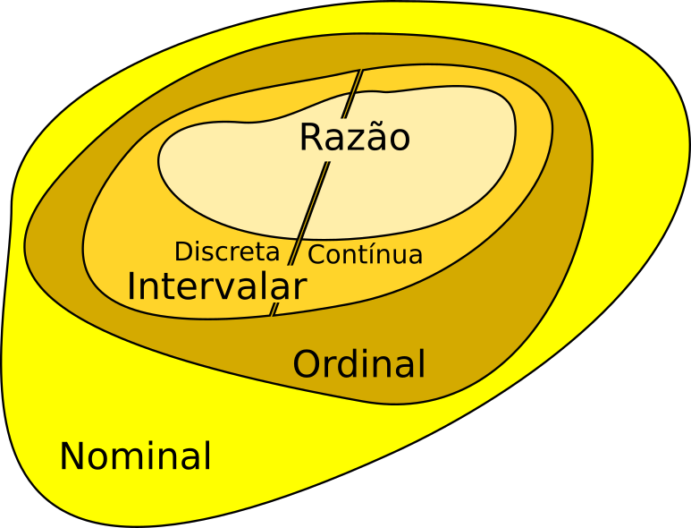

**Exemplo 1.2.9**: Massa, estatura, comprimento, largura, espessura, volume e temperatura de um corpo podem medidas na escala razão.

# Unidade de medida

- [WolframAlpha: 17| Units](https://www.wolfram.com/language/elementary-introduction/2nd-ed/17-units.html)

[10 lb + 10 kg](https://www.wolframalpha.com/input?i=10+lb+%2B+10+kg)

[96 kg / (1.69 m)^2](https://www.wolframalpha.com/input?i=96+kg+%2F+%281.69+m%29%5E2)

[kg / m^2](https://www.wolframalpha.com/input?i=kg+%2F+m%5E2)

[convert mi^3 to ft^3](https://www.wolframalpha.com/input?i=convert+mi%5E3+to+ft%5E3)

```r
MCT <- rnorm(10,70,10)
Estatura <- rnorm(10,1.70,0.7)
units(MCT) <- "kg"
print(MCT)
```

```
Units: [kg]
 [1] 62.88300 74.47111 49.46887 85.67102 78.62575 56.04186 68.12885 71.92019
 [9] 81.75415 77.41059
```

```r
units(Estatura) <- "m"
print(Estatura)
```

```
Units: [m]
 [1] 1.8419756 1.6556097 0.4769816 1.7401979 1.5841588 1.7784868 2.2441066
 [8] 0.9433799 1.1948339 1.6106850
```

```r
IMC <- MCT/Estatura^2
print(IMC)
```

```
Units: [kg/m^2]
 [1]  18.53385  27.16889 217.43460  28.29024  31.33051  17.71786  13.52833
 [8]  80.81232  57.26572  29.83865
```

```r
print(IMC[1])
```

```
18.53385 [kg/m^2]
```

# Um problema com porcentagens

## Crescimento de um potro

Suponha que um biólogo esteja estudando o crescimento de um potro. Quando ele começa sua investigação, o potro pesa 50 kg. O número é simplificado para facilitar a apresentação. Em um mês a massa corporal total (MCT) aumenta 20%, ou seja, 1/5 de 50 kg, e chega a 60 kg. Suponha que em um segundo mês a MCT aumente novamente em 20%; então tendemos a dizer “o aumento total é de 20% + 20% = 40%”.

$$f=w\left(1+\frac{p}{100}\right)^n$$

$n\in\mathbb{N^{*}}$: número de intervalos de tempo

$p\in\mathbb{R_{+}^{*}}$: proporção de aumento da MCT num período de tempo

Este é um exemplo clássico de crescimento composto, onde os ganhos de um período são reinvestidos, por assim dizer, e contribuem para o crescimento em períodos subsequentes. No contexto do crescimento da massa corporal total (MCT) do potro, o erro comum é somar as taxas de crescimento sem considerar o efeito de composição.

No primeiro mês, o potro de 50 kg aumenta sua massa em 20%, o que leva a um aumento de 10 kg, resultando em uma MCT de 60 kg.

Para o segundo mês, o aumento de 20% não é aplicado ao peso original de 50 kg, mas ao novo peso de 60 kg. Isso significa que o aumento é de 20% de 60 kg, não de 50 kg. Vamos calcular o novo peso após o segundo mês para ver por que simplesmente somar as taxas de crescimento (20% + 20% = 40%) não dá uma descrição precisa do aumento total.

$$\text{Aumento no segundo mês} = 60 kg
\times 20\% = 60 kg \times 0.20 = 12 kg$$

$$\text{Novo peso após o segundo mês} =
60 kg + 12 kg = 72 kg$$

Portanto, ao final do segundo mês, o peso do potro é de 72 kg. Para calcular o aumento percentual total, podemos usar a fórmula de crescimento composto ou simplesmente calcular a diferença percentual entre o peso inicial e o final:

$$\text{Aumento percentual total} =
\left( \frac{\text{Peso final} - \text{Peso inicial}}{\text{Peso
inicial}} \right) \times 100\%$$

$$\text{Aumento percentual total} =
\left( \frac{72 kg - 50 kg}{50 kg} \right) \times 100\%$$

Vamos calcular isso para ver como o aumento total é realmente maior do que a soma simples das taxas de aumento mensal.

O aumento percentual total na massa corporal total (MCT) do potro, ao longo dos dois meses, é de 44%. Isso demonstra que o aumento real é maior do que a soma simples das taxas de crescimento mensal (20% + 20% = 40%), devido ao efeito de composição do crescimento.

[$$\left(1+\frac{20}{100}\right)^2=1.44$$](https://www.wolframalpha.com/input?i=%5Cleft%281%2B%5Cfrac%7B20%7D%7B100%7D%5Cright%29%5E2)

```
(1+20/100)^2
quit
```

```
Scilab 2023.1.0 (May 23 2023, 09:23:00)
 ans  =

   1.44
```

```r
(1+20/100)^2
```

```
[1] 1.44
```

```r
w <- 50
r <- 0.2
for (t in 0:2)
{
  cat("\nPeso no tempo t(",t,")=",w,sep="")
  cat("\n\t... aumento de ",r*100,"%",sep="")
  w <- w*(1+r)
}
```

```
Peso no tempo t(0)=50
    ... aumento de 20%
Peso no tempo t(1)=60
    ... aumento de 20%
Peso no tempo t(2)=72
    ... aumento de 20%
```

## [Jacinto d’água](https://pt.wikipedia.org/wiki/Jacinto-de-%C3%A1gua)

- **Problema 1.3.1** O Nilo Branco acima da represa em Jebel Aulia estava infestado por uma erva daninha conhecida como jacinto d’água. Em 1958 a planta cobria apenas 12 km<sup>2</sup>, mas o aumento anual foi de 50%.
1. Qual área foi coberta $1,2, \ldots, n$ anos depois?
2. Quanto tempo levou para cobrir toda a área de remanso de 200 km<sup>2</sup>?

Solução:

1. Área = 12 x 1.5<sup>n</sup> km<sup>2</sup> ($n = 1,2, \ldots$)
2. 12 x 1.5<sup>n</sup> = 200; n x log(1.5) = log(200/12); $n\approx6.94$ anos

Portanto, a água represada foi totalmente coberto em 1965 (= 1958 + 7).

$$12 \times 1.5^n =
200$$

```
log(200/12)/log(1.5)
quit
```

```
Scilab 2023.1.0 (May 23 2023, 09:23:00)
 ans  =

   6.9387246
```

```
deff("[y]=f(x)","y=12*1.5^x - 200")
fsolve(7,f)
quit
```

```
Scilab 2023.1.0 (May 23 2023, 09:23:00)
 ans  =

   6.9387246
```

```r
cat("n =" , log(200/12)/log(1.5))
```

```
n = 6.938725
```

```r
f <- function(x) 12*1.5^x-200
uni <- stats::uniroot(f, c(0, 8))$root
cat("n =", uni)
```

```
n = 6.938745
```

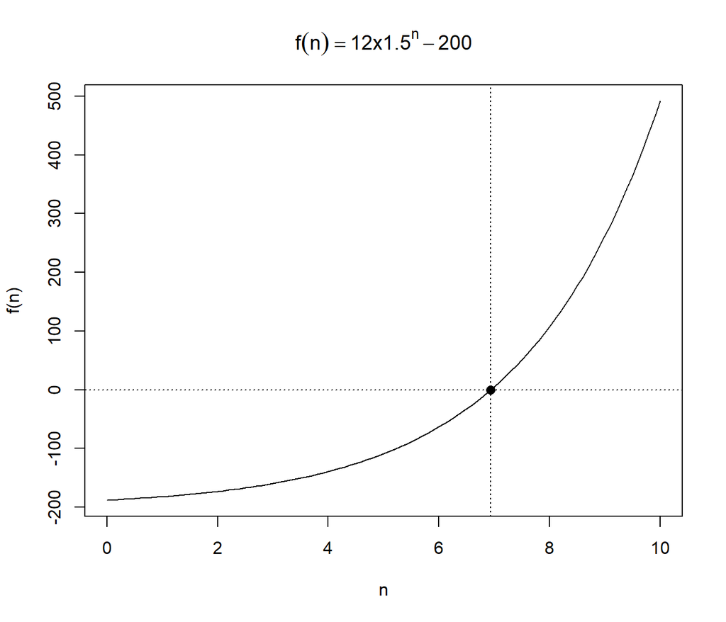

```r
curve(f(x), 0, 10, xlab="n", ylab="f(n)",
      main=expression(f(n)==12*plain(x)*1.5^n-200))
points(uni, 0, pch = 16, cex = 1.2)
abline(h = 0, lty = 3)
abline(v = uni, lty = 3)
```

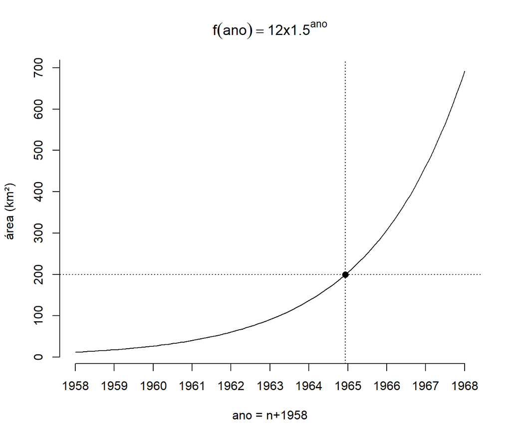

```r
# changing axes
startyear <- 1958
curve(f(x), 0, 10,
      xlab="ano = n+1958",
      ylab="área (km²)",
      axes=FALSE,
      main=expression(f(ano)==12*plain(x)*1.5^ano))
y <- seq(-200,600,by=100)
l <- y+200
axis(2,at=y,labels=l)
axis(1,at=0:10,labels=seq(startyear,startyear+10,by=1))
points(uni, 0, pch = 16, cex = 1.2)
abline(h = 0, lty = 3)
abline(v = uni, lty = 3)
```

```r
area <- 12
r <- 0.5
ano <- ano0 <- 1958
while (1)
{
  cat("\nArea coberta em ",ano," = ",area,sep="")
  delta <- ano-ano0
  if(delta>0) {cat(" (após ",delta," anos)",sep="")}
  if (area >= 200)
  {
    break
  }
  cat("\n\t... aumento de ",r*100,"%",sep="")
  area <- area*(1+r)
  ano <- ano+1
}
```

```
Area coberta em 1958 = 12
    ... aumento de 50%
Area coberta em 1959 = 18 (após 1 anos)
    ... aumento de 50%
Area coberta em 1960 = 27 (após 2 anos)
    ... aumento de 50%
Area coberta em 1961 = 40.5 (após 3 anos)
    ... aumento de 50%
Area coberta em 1962 = 60.75 (após 4 anos)
    ... aumento de 50%
Area coberta em 1963 = 91.125 (após 5 anos)
    ... aumento de 50%
Area coberta em 1964 = 136.6875 (após 6 anos)
    ... aumento de 50%
Area coberta em 1965 = 205.0312 (após 7 anos)
```

$\Diamond$

# Usos incorretos e corretos de porcentagens

Porcentagens só podem ser aplicadas para quantidades medidas em uma escala de proporção/ razão.

- **Exemplo 1.4.4** *Um aumento de 50% e uma diminuição subsequente de 50% não se anulam*. Se, por exemplo, a colheita de uma macieira aumenta de 120 kg para 180 kg em um ano, chamamos isso de aumento de 50%. Uma redução subsequente de 50%, no entanto, geralmente é relacionada a 180 kg como 100%. Assim, a colheita é reduzida para 90 kg em vez dos 120 kg originais.

# Leis algébricas

- [Basic Laws of Algebra](https://en.wikiversity.org/wiki/Basic_Laws_of_Algebra)

Quais expressões a seguir são equivalentes?

1. $1+p/100$
2. $(1+p)/100$
3. $p/100+1$
4. $p/(100+1)$

Resposta:

1. $1+\dfrac{p}{100}$
2. $\dfrac{1+p}{100}$
3. $\dfrac{p}{100}+1$
4. $\dfrac{p}{100+1}$

Portanto, a=c. $\Diamond$

# Números relativos

- [Number line](https://en.wikipedia.org/wiki/Number_line)
- Valor absoluto

$$\begin{align}
|+5|&=5 \\
|-5|&=5
\end{align}$$

[$$\text{absolute}~-5$$](https://www.wolframalpha.com/input?i=absolute+-5)

```r
abs(-5)
```

```
[1] 5
```

```
abs(-5)
quit
```

```
Scilab 2023.1.0 (May 23 2023, 09:23:00)
 ans  =

   5.
```

- *Nunca divida por zero!*

**Exemplo I** Os leitores familiarizados com o símbolo $\infty$ que significa infinito podem estar inclinados a escrever $3/0 = \infty$. No entanto, isso não é correto por dois motivos. Primeiramente, $\infty$ não é um número, de modo que o sinal de igualdade não é aplicável. Em segundo lugar, se $3/0 = \infty$ fosse verdadeiro, $3/0 = -\infty$ também seria verdadeiro. $\Diamond$

**Exemplo II** Observe que a equação $x^2 = px$ não pode ser resolvida adequadamente se dividirmos cada lado por $x$. Perderíamos a solução possível $x = 0$.

Procedendo corretamente, coletamos os dois termos do lado esquerdo, fatoramos $x$ e decidimos que $x$ ou $x - p$ deve ser zero:

$$\begin{align}
x^2&=px \\
x^2-px&=0 \\
x(x-p)&=0
\end{align}$$

Para $p=1$, tem-se $x(x-1)=0$.

[x^2 = x](https://www.wolframalpha.com/input?i=x%5E2+%3D+p+x)

```
// Solucao correta e exata! 0 c -1 x + 1 x^2=0
y = poly([0 -1 1],"x","coeff")
roots(y)
quit
```

```
Scilab 2023.1.0 (May 23 2023, 09:23:00)
 y  =

  -x +x^2
 ans  =

   1. + 0.i
   0. + 0.i
```

```r
# Solucao incorreta!
f <- function(x) x^2 - x
curve(f(x), 0, 2, xlab="x", ylab="f(x)",
      main=expression(x^2-x==0))
uni <- stats::uniroot(f, c(0, 2))$root
cat("x =", uni)
```

```
x = 0
```

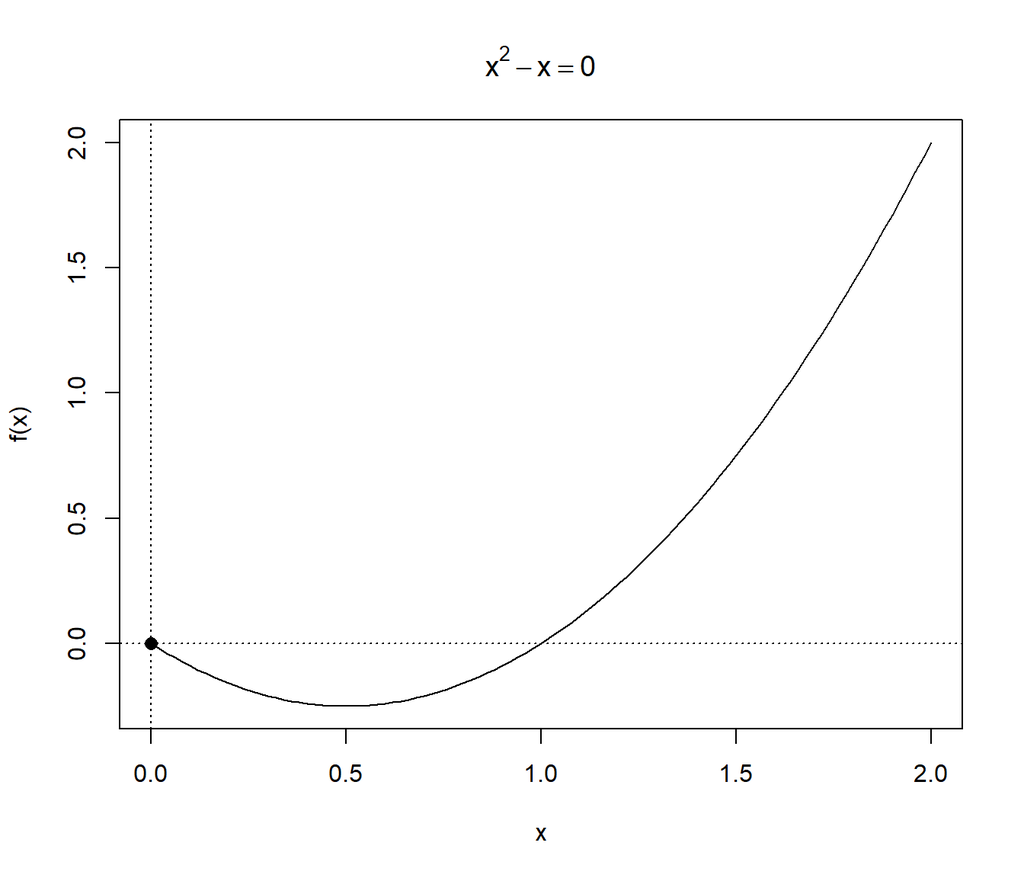

```r
points(uni, 0, pch = 16, cex = 1.2)
abline(h = 0, lty = 3)
abline(v = uni, lty = 3)
```

```r
# Solucao correta, mas aproximada!
f <- function(x) x^2 - x
curve(f(x), -1, 2, xlab="x", ylab="f(x)",
      main=expression(x^2-x==0))
All <- rootSolve::uniroot.all(f, c(-1, 2))
print(All)
```

```
[1] -0.0001680278  1.0001680278
```

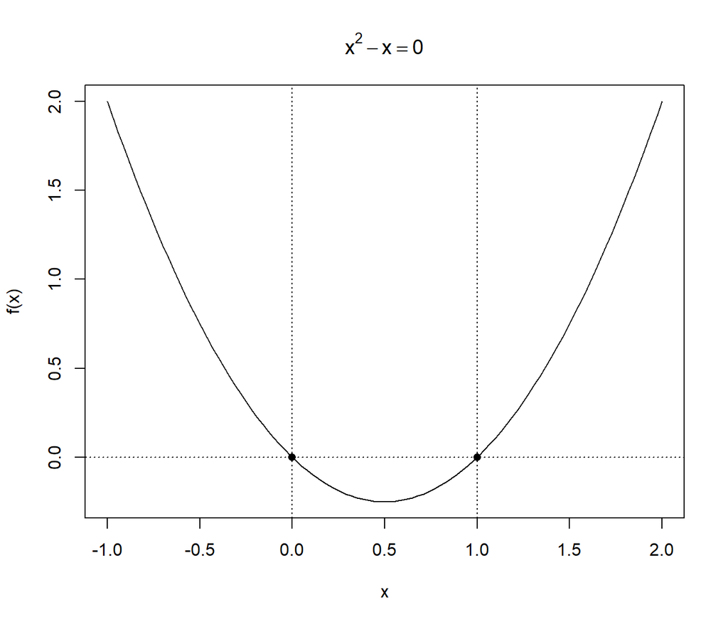

```r
points(All, y = rep(0, length(All)), pch = 16, cex = 1)
abline(h = 0, lty = 3)
abline(v = All[1], lty = 3)
abline(v = All[2], lty = 3)
```

$\Diamond$

# Desigualdades

- Inequality (mathematics)

**Exemplo 1.7.1**: Resolver a inequação: *u* é incógnita e *p* é parâmetro

$$u(u-1)>p-4u+u^2$$

$$\text{solve}~u(u-1)>p-4u+u^2~
\text{for}~u$$

Resposta: $u>p/3$ and $p \in \mathbb{R}$. $\Diamond$

**Exemplo II**: Resolver a inequação

$$x^2<2$$

[$$x^2<2$$](https://www.wolframalpha.com/input?i=x%5E2%3C2)

Resposta: $-\sqrt{2}<x<\sqrt{2}$. $\Diamond$

# Valores médios

- Mean

Quando uma quantidade muda com o tempo ou quando um experimento é repetido várias vezes, temos que condensar a quantidade de dados para fins práticos. Uma maneira de fazer isso é calcular médias ou valores médios.

Quando a quantidade em consideração é intervalar ou razão, o valor médio mais comum é a média aritmética.

$$\bar{x}=\frac{x_{1}+x_{2}}{2}$$

Há ocasiões em que a média aritmética perde seu valor biológico significado.

A média geométrica só é aplicável se as grandezas envolvidas são medidos em uma escala de proporção.

Considere o crescimento de um potro conforme descrito na Seção 1.3.

Em intervalos de tempo equidistantes, o potro atinge os pesos 50kg, 60kg, 72kg.

A sequência foi o resultado da multiplicação de 50 kg repetidamente pelo fator constante 1.2. Achamos que 60 kg é a média adequada entre 50 kg e 72 kg. Porém, a média aritmética é (50 + 72)/2 = 61. Podemos tentar a média geométrica que é definida pela fórmula $x_{g}=\sqrt{x_{1} \times x_{2}}$. Obtemos $\sqrt{50\times72} = \sqrt{3600} = 60$ que é o valor desejado.

$$\begin{align}
x_{g}&=\sqrt{x_{1} \times x_{2}} \\
\log{x_{g}}&=\dfrac{\log{x_{1}} + \log{x_{2}}}{2}
\end{align}$$

$$\log{x_{g}}=\log{\sqrt{x_{1} \times
x_{2}}}=\frac{\log{x_{1}} + \log{x_{2}}}{2}$$

- [mean (a,b,c)](https://www.wolframalpha.com/input?i=mean+%28a%2Cb%2Cc%29)
- [geometric mean (a,b,c)](https://www.wolframalpha.com/input?i=geometric+mean+%28a%2Cb%2Cc%29)
- [harmonic mean (a,b,c)](https://www.wolframalpha.com/input?i=harmonic+mean+%28a%2Cb%2Cc%29)

```r
x <- c(2.4,3.1,2.8,2.9,2.2,2.8)
DescTools::Mean(x)
```

```
[1] 2.7
```

```r
DescTools::Gmean(x)
```

```
[1] 2.681956
```

```r
DescTools::Hmean(x)
```

```
[1] 2.663227
```

```
x = [2.4, 3.1, 2.8, 2.9, 2.2, 2.8]
mean(x)
geomean(x)
harmean(x)
quit
```

```
Scilab 2023.1.0 (May 23 2023, 09:23:00)
 x  =

   2.4   3.1   2.8   2.9   2.2   2.8
 ans  =

   2.7000000
 ans  =

   2.6819558
 ans  =

   2.6632269
```

- Observe que uma fórmula de valor médio não pode ser usada no nível ordinal.

## Exemplos de aplicação de médias aritmética, geométrica e harmônica

- [Média aritmética: UOL Mundo Educação](https://mundoeducacao.uol.com.br/matematica/media-aritmetica.htm)
- [Média geométrica: UOL Mundo Educação](https://mundoeducacao.uol.com.br/matematica/media-geometrica.htm)
- [Média harmônica: UOL Mundo Educação](https://mundoeducacao.uol.com.br/matematica/media-harmonica.htm)

# Somatório

$$\begin{align}
\bar{x}&=\dfrac{x_{1}+x_{2}+\cdots+x_{n}}{n}=\dfrac{\sum_{i=1}^{n}{x_{i}}}{n}
\\
\bar{x}&=\dfrac{\sum_{i=1}^{n}{x_{i}}}{n}=\dfrac{1}{n}\sum_{i=1}^{n}{x_{i}}=\sum_{i=1}^{n}{\dfrac{x_{i}}{n}}
\end{align}$$

- Mostre que o somatório dos desvios é nulo, i.e., $\sum_{i=1}^{n}{\left(x_{i}-\bar{x}\right)}=0$.
- Mostre que a média dos desvios absolutos é positiva, i.e.,$\dfrac{1}{n}\sum_{i=1}^{n}{\left|x_{i}-\bar{x}\right|}\ge0$.
- Mostre que a média dos desvios ao quadrado (variância populacional) é positiva, i.e., $\dfrac{1}{n}\sum_{i=1}^{n}{\left(x_{i}-\bar{x}\right)^2}\ge0$.

**Exemplo**:

| $x_{i}$ | $x_{i}-\bar{x}$ | $\left(x_{i}-\bar{x}\right)^2$ |
| --- | --- | --- |
| 2.4 | -0.3 | 0.09 |
| 3.1 | +0.4 | 0.16 |
| 2.8 | +0.1 | 0.01 |
| 2.9 | +0.2 | 0.04 |
| 2.2 | -0.5 | 0.25 |
| 2.8 | +0.1 | 0.01 |
| —- | —— | ——— |
| 16.2 | 0 | 0.56 |

- Média: $\bar{x}=16.2/6=2.7$
- Variância populacional: $s^2=0.56/6=0.09\bar{3}$

[mean (2.4, 3.1, 2.8, 2.9, 2.2, 2.8)](https://www.wolframalpha.com/input?i=mean+%282.4%2C+3.1%2C+2.8%2C+2.9%2C+2.2%2C+2.8%29)

[population variance (2.4, 3.1, 2.8, 2.9, 2.2, 2.8)](https://www.wolframalpha.com/input?i=population+variance+%282.4%2C+3.1%2C+2.8%2C+2.9%2C+2.2%2C+2.8%29+)

```r
x <- c(2.4, 3.1, 2.8, 2.9, 2.2, 2.8)
mean(x)
```

```
[1] 2.7
```

```r
var(x)*((length(x)-1)/length(x))
```

```
[1] 0.09333333
```

```
x = [2.4, 3.1, 2.8, 2.9, 2.2, 2.8]
mean(x)
variance(x)*5/6
variance(x,"*", %nan)
quit
```

```
Scilab 2023.1.0 (May 23 2023, 09:23:00)
 x  =

   2.4   3.1   2.8   2.9   2.2   2.8
 ans  =

   2.7000000
 ans  =

   0.0933333
 ans  =

   0.0933333
```

$\Diamond$

# Potências

- Exponentiation
- [Múltiplos e submúltiplos em SI](https://www.forp.usp.br/restauradora/pg/metrologia/metrologia_eletric/mult_submult.html)

Exemplos são $\mu$g (micrograma), $\mu$m (micrômetro, anteriormente denotado apenas por $\mu$), nm (nanômetro), MHz (Megahertz = 10<sup>6</sup> ciclos por segundo), mHz (Millihertz = 10<sup>-3</sup> ciclos por segundo).

A unidade ppm indica quantas “partes por milhão” estão envolvidas. Assim, 1 mg significa 1 ppm em relação a 1 kg. Da mesma forma, 1 cm<sup>3</sup> é 1 ppm em relação a 1 m<sup>3</sup>.

Portanto, recíprocos como 1/A também são escritos como A<sup>-1</sup>. Da mesma forma, encontramos m seg<sup>-1</sup> em vez de m/s para a unidade de velocidade.

Em relação às potências de dez, mencionamos a frase “ordem de magnitude”. Quando se diz que duas quantidades são de diferentes ordens de magnitude, isso pode significar que elas não são comparáveis em tamanho ou que uma quantidade é pelo menos dez vezes maior que a outra. “Duas ordens de grandeza” significaria então um fator de cerca de 10<sup>2</sup> = 100.

**Problema 1.10.1** Lampert et al. (1969) mediram a massa seca de partículas do vírus herpes simplex (cepa 11140) por meio de um microscópio eletrônico. O núcleo tem massa de 2 x 10<sup>-16</sup> g, o capsídeo nu vazio 5 x 10<sup>-16</sup> g, o capsídeo nu completo 7 x 10<sup>-16</sup> g e o nucleocapsídeo envelopado 13 x 10<sup>-16</sup> g. De que ordem de grandeza é a massa de uma partícula completa do vírus herpes simplex?

Solução: A adição dos valores aproximados acima leva a 1.5 x 10<sup>-15</sup> g. Portanto, a ordem de grandeza é 10<sup>-15</sup> g. Isso é oito ordens de grandeza maior do que a massa de uma única molécula de oxigênio (5 x 10<sup>-23</sup> g).

$\Diamond$

**Problema 1.10.2** A capacidade de oxigênio do sangue dos mamíferos é de cerca de 200 ml por litro de sangue. Se totalmente utilizada, esta quantidade de oxigênio produzirá uma energia de 4.2 x 10<sup>3</sup> J (Joule).

1. Em quantos graus Celsius a temperatura de 1 litro de sangue pode ser aumentada por essa energia?
2. Quantos metros um homem de 70 kg pode escalar até consumir o oxigênio de seus 3.5 litros de sangue?

Solução:

1. O sangue se comporta como a água, quando aquecido: Um litro precisa da energia de 4.2 x 10<sup>3</sup> J ou mil calorias (kcal ou C) para um aumento de temperatura de 1<sup>o</sup> C. E esta é exatamente a energia que o oxigênio no sangue pode fornecer. Portanto, a resposta é 1<sup>o</sup> C.
2. A energia necessária para erguer uma massa de 1 kg por 1 m é 9.81 Nm (Newtonmetro) = 9.81 J. Portanto, para cada metro para subir, um homem de 70 kg requer uma energia de 70 x 9.81 J m<sup>-1</sup>. A energia contida em 3.5 litros de sangue é 3.5 x 4.2 x 10<sup>3</sup> J = 14.7 x 10<sup>3</sup> J. Essa energia é suficiente para subir (14.7 x 10<sup>3</sup> J)/(70 x 9.81 J m<sup>-1</sup>) = 21 m.

Assim, ao subir, o corpo tem que renovar seu conteúdo de oxigênio pelo menos a cada 21 metros. $\Diamond$

# Potências fracionárias

$$\sqrt{x^2}=|x|$$

[`\sqrt{x^2}`](https://www.wolframalpha.com/input?i=%5Csqrt%7Bx%5E2%7D)

# Cálculos com números aproximados

Os pesquisadores estão frequentemente preocupados com a imprecisão dos números.

Uma fonte são erros na contagem ou incertezas nos instrumentos de leitura.

Outra fonte são as flutuações aleatórias na amostragem.

Finalmente, os inevitáveis erros de arredondamento também causam algumas dificuldades.

Suponha que um número como 14.07 tenha um erro não superior a 0.005, ou seja, um erro não maior que a metade do último dígito. Então o último decimal 7 é exato e dizemos que 14.07 tem quatro dígitos significativos (ou algarismos).

**Problema**: Quantos dígitos significativos tem o número 380?

Solução:

3.8 x 10<sup>2</sup> tem dois dígitos significativos.

3.80 x 10<sup>2</sup> tem três dígitos significativos.

O erro é no máximo 0.05 x 10<sup>2</sup> para o primeiro número e no máximo 0.005 x 10<sup>2</sup> para o segundo número. Sem potências, ambos os números seriam 380, não indicando, portanto, a precisão. $\Diamond$

**Exemplo**: Arredondar para uma casa decimal, arredondar para o menor e maior inteiro, e truncar os números 4.65 e 4.75.

Solução:

Pode ser aplicado pela regra: 5 é arredondado para baixo sempre que o algarismo precedente é par e é arredondado para cima sempre que o algarismo anterior é ímpar. Assim, 4.65 e 4.75 são arredondados para 4.6 e 4.8, respectivamente.

Arredondar para uma casa decimal 4.65 = 4.6

Arredondar para uma casa decimal 4.75 = 4.8

Arredondar para o menor inteiro 4.65 = 4

Arredondar para o menor inteiro 4.75 = 4

Arredondar para o maior inteiro 4.65 = 5

Arredondar para o maior inteiro 4.75 = 5

Truncar 4.65 = 4

Truncar 4.75 = 4

[`round to 2 digits 4.65`](https://www.wolframalpha.com/input?i=round+to+2+digits+4.65)

[`round to 2 digits 4.75`](https://www.wolframalpha.com/input?i=round+to+2+digits+4.65)

| Comando | Aparência | Resultado |
| --- | --- | --- |
| round to 2 digits 4.05 | 4.1 | 4.0 |
| round to 2 digits 4.15 | 4.2 | 4.2 |
| round to 2 digits 4.25 | 4.3 | 4.3 |
| round to 2 digits 4.35 | 4.4 | 4.4 |
| round to 2 digits 4.45 | 4.5 | 4.4 |
| round to 2 digits 4.55 | 4.6 | 4.5 |
| round to 2 digits 4.65 | 4.7 | 4.6 |
| round to 2 digits 4.75 | 4.8 | 4.8 |
| round to 2 digits 4.85 | 4.9 | 4.9 |
| round to 2 digits 4.95 | 5.0 | 5.0 |

| Comando | Aparência | Resultado |
| --- | --- | --- |
| round to 3 digits 14.05 | 14.1 | 14.0 |
| round to 3 digits 14.15 | 14.2 | 14.2 |
| round to 3 digits 14.25 | 14.3 | 14.2 |
| round to 3 digits 14.35 | 14.4 | 14.4 |
| round to 3 digits 14.45 | 14.5 | 14.4 |
| round to 3 digits 14.55 | 14.6 | 14.5 |
| round to 3 digits 14.65 | 14.7 | 14.7 |
| round to 3 digits 14.75 | 14.8 | 14.7 |
| round to 3 digits 14.85 | 14.9 | 14.9 |
| round to 3 digits 14.95 | 15.0 | 15.0 |

| Comando | Aparência | Resultado |
| --- | --- | --- |
| round to 1 digits 0.05 | 0.05 | 0.05 |
| round to 1 digits 0.15 | 0.2 | 0.1 |
| round to 1 digits 0.25 | 0.3 | 0.2 |
| round to 1 digits 0.35 | 0.4 | 0.4 |
| round to 1 digits 0.45 | 0.5 | 0.4 |
| round to 1 digits 0.55 | 0.6 | 0.6 |
| round to 1 digits 0.65 | 0.7 | 0.6 |
| round to 1 digits 0.75 | 0.8 | 0.8 |
| round to 1 digits 0.85 | 0.9 | 0.9 |
| round to 1 digits 0.95 | 1.0 | 0.9 |

```r
round(4.65,1)
```

```
[1] 4.7
```

```r
round(4.75,1)
```

```
[1] 4.8
```

```r
floor(4.65)
```

```
[1] 4
```

```r
floor(4.75)
```

```
[1] 4
```

```r
ceiling(4.65)
```

```
[1] 5
```

```r
ceiling(4.75)
```

```
[1] 5
```

```r
trunc(4.65)
```

```
[1] 4
```

```r
trunc(4.75)
```

```
[1] 4
```

```
round(4.75)
quit
```

```
Scilab 2023.1.0 (May 23 2023, 09:23:00)
 ans  =

   5.
```

```
round(4.65)
quit
```

```
Scilab 2023.1.0 (May 23 2023, 09:23:00)
 ans  =

   5.
```

```
floor(4.65)
quit
```

```
Scilab 2023.1.0 (May 23 2023, 09:23:00)
 ans  =

   4.
```

```
floor(4.75)
quit
```

```
Scilab 2023.1.0 (May 23 2023, 09:23:00)
 ans  =

   4.
```

```
ceil(4.65)
quit
```

```
Scilab 2023.1.0 (May 23 2023, 09:23:00)
 ans  =

   5.
```

```
ceil(4.75)
quit
```

```
Scilab 2023.1.0 (May 23 2023, 09:23:00)
 ans  =

   5.
```

```
int(4.65)
quit
```

```
Scilab 2023.1.0 (May 23 2023, 09:23:00)
 ans  =

   4.
```

```
int(4.75)
quit
```

```
Scilab 2023.1.0 (May 23 2023, 09:23:00)
 ans  =

   4.
```

O resultado de uma multiplicação ou divisão tem aproximadamente o mesmo número de dígitos significativos que o termo com o menor número de dígitos significativos.

Ocasionalmente, o número de dígitos significativos é aumentado. Isso pode acontecer com a média aritmética de dez ou mais medições se a dispersão for pequena o suficiente. Por razões que não podem ser explicadas aqui, a precisão da média aritmética é maior do que a das medições individuais. Por exemplo, suponha que dez folhas de uma árvore sejam selecionadas aleatoriamente e seus comprimentos medidos em cm sejam:

5.8 6.1 5.7 5.6 6.2 5.8 5.9 6.2 6.0 5.9.

Cada medição contém dois dígitos significativos. A média aritmética deve ser escrita 5.92 e tem uma precisão maior que dois dígitos significativos.

[`14.04 2.3/39.7`](https://www.wolframalpha.com/input?i=14.04+2.3%2F39.7)

```r
14.04*2.3/39.7
```

```
[1] 0.8134005
```

```
14.04*2.3/39.7
quit
```

```
Scilab 2023.1.0 (May 23 2023, 09:23:00)
 ans  =

   0.8134005
```

# Uma aplicação

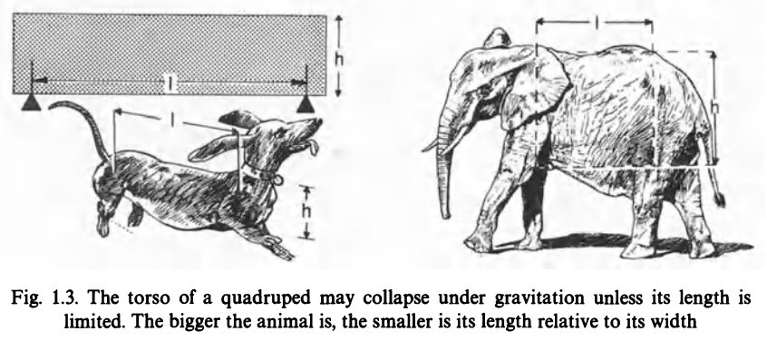

Para ilustrar o uso de potências fracionárias em biologia, consideramos a forma de quadrúpedes (Fig. 1.3). $l$ denota o comprimento de um quadrúpede medido do quadril ao ombro e $h$ denota a largura que é a espessura média do corpo medida na direção vertical. Então o tronco é comparado com uma barra uniforme de comprimento $l$ e largura $h$ apoiada em suas extremidades. A gravidade causa encurvamento da barra. A física mostra que a razão é limitada por algum valor. Se a proporção exceder esse valor, a barra cede.

$$l/h^{2/3}$$

Embora o torso de um animal seja um sistema complicado que consiste em ossos, músculos e tendões e, portanto, bastante diferente de uma barra uniforme, a aplicação da razão $l/h^{2/3}$ indica aproximadamente a limitação do comprimento dos quadrúpedes.

Alguns dos valores mais altos alcançados pelos quadrúpedes são:

| Mamífero Quadrúpede | $l$ cm | $h$ cm | $l/h^{2/3}$ |
| --- | --- | --- | --- |
| Arminho (Mustela erminea) | 12 | 4 | 4.8 |
| Bassê | 35 | 12 | 6.7 |
| Tigre indiano (Panthera tigres) | 90 | 45 | 7.1 |
| Lhama (Lama glama) | 122 | 73 | 7.0 |
| Elefante indiano (Elephas maximus) | 153 | 135 | 5.8 |

[`12/4^{2/3}`](https://www.wolframalpha.com/input?i=12%2F4%5E%282%2F3%29)

```r
12/4^(2/3)
```

```
[1] 4.762203
```

```
12/4^(2/3)
quit
```

```
Scilab 2023.1.0 (May 23 2023, 09:23:00)
 ans  =

   4.7622032
```

# Número real em YouTube

- [Thomas Frank: How to Get Better at Math](https://www.youtube.com/watch?v=HPsazrVSjl8&t=420s)
- [Eric Rowland: An Exact Formula for the Primes: Willans’ Formula](https://www.youtube.com/watch?v=j5s0h42GfvM)
- [The Rhythm of The Primes](https://www.youtube.com/watch?v=8x374slJGuo)
- [D!NG: A Proof That The Square Root of Two Is Irrational](https://www.youtube.com/watch?v=LmpAntNjPj0)
- [Dennis Wildfogel: Quão grande é o infinito?](https://www.youtube.com/watch?v=UPA3bwVVzGI)
- [Matemática da Támires: NUNCA MAIS ERRE PROBLEMA COM TORNEIRAS](https://www.youtube.com/watch?v=tvc_Ycp-9qg&t=7s)

# Bibliografia: Aula01: Número real

- Batschelet, E (1979) *Introduction to mathematics for life scientists*. 3rd ed. NY: Springer.
- Batschelet, E (1978) *Introdução à matemática para biocientistas*. Tradução da 2ª ed. São Paulo: EDUSP e Rio de Janeiro: Interciência.
- Giordano, FR et al. (2015) *A first course in mathematical modeling*. 5th ed. OH: Thomson. Capítulo 14: Dimensional Analysis and Similitude.
- Pauli, RU et al. (1980) *Física 4: eletricidade, magnetismo, física moderna e análise dimensional*. São Paulo: EPU O livro apresenta a análise dimensional de forma didática e aplicada à Física.
- Simão, C (1980) *Manual do professor de física 4 de Pauli et al.* São Paulo: EPU.
- Siqueira, JO (2011) *Fundamentos para cálculo*: usando WolframAlpha. São Paulo: Saraiva. Soluções dos exercícios em https://www.researchgate.net/publication/326533655_Fundamentos_para_Calculo_-_Solucoes.

# Simplificação em R

```r
nlsr::nlsSimplify(quote((a+b) + (a+b))) ## 2 * (a + b)
```

```
2 * (a + b)
```

```r
nlsr::nlsSimplify(quote((a+b) - (a+b))) ## 0
```

```
[1] 0
```

```r
nlsr::nlsSimplify(quote(log(exp(a+b)))) ## a + b
```

```
a + b
```

```r
nlsr::nlsSimplify(quote(exp(log(a+b)))) ## a + b
```

```
a + b
```

```r
Deriv::Simplify(quote((a+b) + (a+b))) ## 2 * (a + b)
```

```
2 * (a + b)
```

```r
Deriv::Simplify(quote((a+b) - (a+b))) ## 0
```

```
[1] 0
```

```r
Deriv::Simplify(quote(log(exp(a+b)))) ## a + b
```

```
a + b
```

```r
Deriv::Simplify(quote(exp(log(a+b)))) ## exp(log(a + b))
```

```
exp(log(a + b))
```

# Tipos numéricos em R

```r
x <- 1L
is.integer(x) # TRUE
```

```
[1] TRUE
```

```r
x <- 1:3
is.integer(x) # TRUE
```

```
[1] TRUE
```

```r
x <- seq(1,3)
is.integer(x) # TRUE
```

```
[1] TRUE
```

```r
x <- 1
is.double(x) # TRUE
```

```
[1] TRUE
```

```r
x <- 1L
x <- as.double(x)
is.double(x) # TRUE
```

```
[1] TRUE
```

```r
pi # 3.141593
```

```
[1] 3.141593
```

```r
is.double(pi) # TRUE
```

```
[1] TRUE
```

```r
x <- "3.141593"
is.character(x) # TRUE
```

```
[1] TRUE
```

```r
x <- as.double(x)
is.double(x) # TRUE
```

```
[1] TRUE
```

```r
x <- "3.141593"
is.character(x) # TRUE
```

```
[1] TRUE
```

```r
nchar(x) # 8
```

```
[1] 8
```

```r
x <- as.numeric(x)
is.double(x) # TRUE
```

```
[1] TRUE
```

```r
z <- 1 + 3i
is.complex(z) # TRUE
```

```
[1] TRUE
```

```r
Re(z) # 1
```

```
[1] 1
```

```r
Im(z) # 3
```

```
[1] 3
```

```r
Mod(z) # h = √(x^2 + y^2) = 3.162278
```

```
[1] 3.162278
```

```r
Arg(z) # angle = 1.249046
```

```
[1] 1.249046
```

```r
Conj(z) # 1-3i
```

```
[1] 1-3i
```

# Arredondamento em R

```r
options(digits=7) # default
pi # 3.141593
```

```
[1] 3.141593
```

```r
round(x=pi) # 3
```

```
[1] 3
```

```r
round(x=pi, digits=0) # 3
```

```
[1] 3
```

```r
round(x=pi, digits=2) # 3.14
```

```
[1] 3.14
```

```r
round(x=pi, digits=20) # 3.141593
```

```
[1] 3.141593
```

```r
signif(x=pi, digits=1) # 3
```

```
[1] 3
```

```r
signif(x=pi, digits=2) # 3.1
```

```
[1] 3.1
```

```r
signif(x=pi, digits=3) # 3.14
```

```
[1] 3.14
```

```r
trunc(x=pi) # 3
```

```
[1] 3
```

```r
ceiling(pi) # 4
```

```
[1] 4
```

```r
floor(pi) # 3
```

```
[1] 3
```

```r
options(digits=15) # default
round(x=pi, digits=15) # 3.14159265358979
```

```
[1] 3.14159265358979
```

```r
options(digits=20) # default
round(x=pi, digits=20) # 3.1415926535897931???
```

```
[1] 3.141592653589793116
```

# Formatação numérica em R

```r
options(digits=7) # default
x <- pi
x # 3.141593
```

```
[1] 3.141593
```

```r
options(digits=3)
x # 3.14
```

```
[1] 3.14
```

```r
x <- pi # 3.141593
f <- format(x) # "3.141593"
str(f) # chr "3.141593"
```

```
 chr "3.14"
```

```r
print(f, quote=FALSE) # 3.141593
```

```
[1] 3.14
```

```r
noquote(f) # 3.141593
```

```
[1] 3.14
```

```r
f <- as.double(f) # 3.14 < 3.141593
str(f) # num 3.14
```

```
 num 3.14
```

```r
toString(x) # "3.14159265358979"
```

```
[1] "3.14159265358979"
```

```r
noquote(toString(x)) # 3.14159265358979
```

```
[1] 3.14159265358979
```

```r
format(x, digits=7) # 3.141593
```

```
[1] "3.141593"
```

```r
format(x, digits=17) # 3.1415926535897931
```

```
[1] "3.1415926535897931"
```

```r
format(x/10, scientific=TRUE) # 3.141593e-01
```

```
[1] "3.14e-01"
```

```r
format(c(6.0, 13.1), digits=2) # " 6" "13"
```

```
[1] " 6" "13"
```

```r
format(c(6.0, 13.1), digits=2, nsmall=1) # " 6.0" "13.1"
```

```
[1] " 6.0" "13.1"
```

```r
format(2, nsmall=4) # 2.0000
```

```
[1] "2.0000"
```

```r
format(round(2.001, 2), nsmall=2) # 2.00
```

```
[1] "2.00"
```

```r
format(2.1, decimal.mark=",") # "2,1"
```

```
[1] "2,1"
```

```r
format('Running', justify='r', width=9) # "  Running"
```

```
[1] "  Running"
```

```r
format('Running', justify='c', width=12) # "  Running   "
```

```
[1] "  Running   "
```

```r
# various formats of pi
sprintf("%f", pi)       # "3.141593"
```

```
[1] "3.141593"
```

```r
sprintf("%.3f", pi)     # "3.142"
```

```
[1] "3.142"
```

```r
sprintf("%1.0f", pi)    # "3"
```

```
[1] "3"
```

```r
sprintf("%5.1f", pi)    # "  3.1"
```

```
[1] "  3.1"
```

```r
sprintf("%05.1f", pi)   # "003.1"
```

```
[1] "003.1"
```

```r
sprintf("%+f", pi)      # "+3.141593"
```

```
[1] "+3.141593"
```

```r
sprintf("% f", pi)      # " 3.141593"
```

```
[1] " 3.141593"
```

```r
sprintf("%-10f", pi)    # "3.141593  "
```

```
[1] "3.141593  "
```

```r
sprintf("%e", pi)       # "3.141593e+00"
```

```
[1] "3.141593e+00"
```

```r
sprintf("%E", pi)       # "3.141593E+00"
```

```
[1] "3.141593E+00"
```

```r
sprintf("%g", pi)       # "3.14159"
```

```
[1] "3.14159"
```

```r
sprintf("%g", 1e6*pi)   # "3.14159e+06"
```

```
[1] "3.14159e+06"
```

```r
sprintf("%.9g", 1e6*pi) # "3141592.65"
```

```
[1] "3141592.65"
```

```r
sprintf("%G", 1e-6*pi)  # "3.14159E-06"
```

```
[1] "3.14159E-06"
```

```r
sprintf("%.*f", 54, pi)
```

```
[1] "3.141592653589793115997963468544185161590576171875000000"
```

```r
# "3.141592653589793115997963468544185161590576171875000000"

sprintf(paste0("e with %2d digits = %.",
               1:18, "g"),
        1:18, exp(1))
```

```
 [1] "e with  1 digits = 3"
 [2] "e with  2 digits = 2.7"
 [3] "e with  3 digits = 2.72"
 [4] "e with  4 digits = 2.718"
 [5] "e with  5 digits = 2.7183"
 [6] "e with  6 digits = 2.71828"
 [7] "e with  7 digits = 2.718282"
 [8] "e with  8 digits = 2.7182818"
 [9] "e with  9 digits = 2.71828183"
[10] "e with 10 digits = 2.718281828"
[11] "e with 11 digits = 2.7182818285"
[12] "e with 12 digits = 2.71828182846"
[13] "e with 13 digits = 2.718281828459"
[14] "e with 14 digits = 2.718281828459"
[15] "e with 15 digits = 2.71828182845905"
[16] "e with 16 digits = 2.718281828459045"
[17] "e with 17 digits = 2.7182818284590451"
[18] "e with 18 digits = 2.71828182845904509"
```

```r
sprintf("%09s", month.name)
```

```
 [1] "  January" " February" "    March" "    April" "      May" "     June"
 [7] "     July" "   August" "September" "  October" " November" " December"
```

```r
# [1] "  January" " February" "    March" "    April"
# [5] "      May" "     June" "     July" "   August"
# [9] "September" "  October" " November" " December"

xx <- pi * 10^(-5:4)
cbind(format(xx, digits = 4), formatC(xx))
```

```
      [,1]        [,2]
 [1,] "3.142e-05" "3.142e-05"
 [2,] "3.142e-04" "0.0003142"
 [3,] "3.142e-03" "0.003142"
 [4,] "3.142e-02" "0.03142"
 [5,] "3.142e-01" "0.3142"
 [6,] "3.142e+00" "3.142"
 [7,] "3.142e+01" "31.42"
 [8,] "3.142e+02" "314.2"
 [9,] "3.142e+03" "3142"
[10,] "3.142e+04" "3.142e+04"
```

```r
cbind(formatC(xx, width = 9, flag = "-"))
```

```
      [,1]
 [1,] "3.142e-05"
 [2,] "0.0003142"
 [3,] "0.003142 "
 [4,] "0.03142  "
 [5,] "0.3142   "
 [6,] "3.142    "
 [7,] "31.42    "
 [8,] "314.2    "
 [9,] "3142     "
[10,] "3.142e+04"
```

```r
cbind(formatC(xx, digits = 5,
              width = 8, format = "f", flag = "0"))
```

```
      [,1]
 [1,] "00.00003"
 [2,] "00.00031"
 [3,] "00.00314"
 [4,] "00.03142"
 [5,] "00.31416"
 [6,] "03.14159"
 [7,] "31.41593"
 [8,] "314.15927"
 [9,] "3141.59265"
[10,] "31415.92654"
```

```r
cbind(format(xx, digits = 4),
      formatC(xx, digits = 4, format = "fg"))
```

```
      [,1]        [,2]
 [1,] "3.142e-05" "0.00003142"
 [2,] "3.142e-04" "0.0003142"
 [3,] "3.142e-03" "0.003142"
 [4,] "3.142e-02" "0.03142"
 [5,] "3.142e-01" "0.3142"
 [6,] "3.142e+00" "3.142"
 [7,] "3.142e+01" "31.42"
 [8,] "3.142e+02" "314.2"
 [9,] "3.142e+03" " 3142"
[10,] "3.142e+04" "31416"
```

```r
## individual formatting to common width:
fc <- formatC(1.234 + 10^(0:8), format = "fg",
              width = 11, big.mark = ",")
cbind(fc)
```

```
      fc
 [1,] "      2.234"
 [2,] "      11.23"
 [3,] "      101.2"
 [4,] "      1,001"
 [5,] "     10,001"
 [6,] "    100,001"
 [7,] "  1,000,001"
 [8,] " 10,000,001"
 [9,] "100,000,001"
```

```r
sprintf("(w-1):%s", c("xyz", NA, "abc"))
```

```
[1] "(w-1):xyz" "(w-1):NA"  "(w-1):abc"
```

```r
crfsuite::txt_sprintf("(w-1):%s", c("xyz", NA, "abc"))
```

```
[1] "(w-1):xyz" NA          "(w-1):abc"
```

```r
sprintf("(w-1):%s_%s", c("xyz", NA, "abc"), c(NA, "xyz", "abc"))
```

```
[1] "(w-1):xyz_NA"  "(w-1):NA_xyz"  "(w-1):abc_abc"
```

```r
crfsuite::txt_sprintf("(w-1):%s_%s", c("xyz", NA, "abc"), c(NA, "xyz", "abc"))
```

```
[1] NA              NA              "(w-1):abc_abc"
```